# Risk Factor Analysis

## Outcome Variable

**Outcome Variable:** ever_stunted

## Predictor Variables

**Intervention Variable:** cleanck

**Adjustment Set:**

- arm
- sex
- W_mage
- meducyrs
- feducyrs
- hhwealth_quart
- W_nrooms
- W_nhh
- W_nchldlt5
- trth2o
- impfloor
- delta_meducyrs
- delta_feducyrs
- delta_hhwealth_quart
- delta_W_nrooms
- delta_W_nhh
- delta_W_nchldlt5
- delta_trth2o
- delta_impfloor

## Stratifying Variables

The analysis was stratified on these variable(s):

- agecat
- studyid
- country

## Data Summary

| agecat | studyid | country | cleanck | ever_stunted | n_cell | n |
| --- | --- | --- | --- | --- | --- | --- |
| 0-6 months | ki0047075b-MAL-ED | PERU | 0 | 0 | 1 | 2 |
| 0-6 months | ki0047075b-MAL-ED | PERU | 1 | 0 | 1 | 2 |
| 0-6 months | ki0047075b-MAL-ED | SOUTH AFRICA | 0 | 0 | 1 | 3 |
| 0-6 months | ki0047075b-MAL-ED | SOUTH AFRICA | 0 | 1 | 0 | 3 |
| 0-6 months | ki0047075b-MAL-ED | SOUTH AFRICA | 1 | 0 | 0 | 3 |
| 0-6 months | ki0047075b-MAL-ED | SOUTH AFRICA | 1 | 1 | 2 | 3 |
| 0-6 months | ki1000108-CMC-V-BCS-2002 | INDIA | 0 | 0 | 151 | 368 |
| 0-6 months | ki1000108-CMC-V-BCS-2002 | INDIA | 0 | 1 | 55 | 368 |
| 0-6 months | ki1000108-CMC-V-BCS-2002 | INDIA | 1 | 0 | 141 | 368 |
| 0-6 months | ki1000108-CMC-V-BCS-2002 | INDIA | 1 | 1 | 21 | 368 |
| 0-6 months | ki1000108-IRC | INDIA | 0 | 0 | 144 | 400 |
| 0-6 months | ki1000108-IRC | INDIA | 0 | 1 | 25 | 400 |
| 0-6 months | ki1000108-IRC | INDIA | 1 | 0 | 208 | 400 |
| 0-6 months | ki1000108-IRC | INDIA | 1 | 1 | 23 | 400 |
| 0-6 months | ki1017093b-PROVIDE | BANGLADESH | 0 | 0 | 113 | 700 |
| 0-6 months | ki1017093b-PROVIDE | BANGLADESH | 0 | 1 | 16 | 700 |
| 0-6 months | ki1017093b-PROVIDE | BANGLADESH | 1 | 0 | 521 | 700 |
| 0-6 months | ki1017093b-PROVIDE | BANGLADESH | 1 | 1 | 50 | 700 |
| 0-6 months | ki1017093c-NIH-Crypto | BANGLADESH | 0 | 0 | 184 | 577 |
| 0-6 months | ki1017093c-NIH-Crypto | BANGLADESH | 0 | 1 | 33 | 577 |
| 0-6 months | ki1017093c-NIH-Crypto | BANGLADESH | 1 | 0 | 314 | 577 |
| 0-6 months | ki1017093c-NIH-Crypto | BANGLADESH | 1 | 1 | 46 | 577 |
| 0-6 months | ki1113344-GMS-Nepal | NEPAL | 0 | 0 | 468 | 537 |
| 0-6 months | ki1113344-GMS-Nepal | NEPAL | 0 | 1 | 60 | 537 |
| 0-6 months | ki1113344-GMS-Nepal | NEPAL | 1 | 0 | 9 | 537 |
| 0-6 months | ki1113344-GMS-Nepal | NEPAL | 1 | 1 | 0 | 537 |
| 6-24 months | ki0047075b-MAL-ED | SOUTH AFRICA | 1 | 0 | 1 | 1 |
| 6-24 months | ki1000108-CMC-V-BCS-2002 | INDIA | 0 | 0 | 39 | 288 |
| 6-24 months | ki1000108-CMC-V-BCS-2002 | INDIA | 0 | 1 | 111 | 288 |
| 6-24 months | ki1000108-CMC-V-BCS-2002 | INDIA | 1 | 0 | 58 | 288 |
| 6-24 months | ki1000108-CMC-V-BCS-2002 | INDIA | 1 | 1 | 80 | 288 |
| 6-24 months | ki1000108-IRC | INDIA | 0 | 0 | 98 | 331 |
| 6-24 months | ki1000108-IRC | INDIA | 0 | 1 | 38 | 331 |
| 6-24 months | ki1000108-IRC | INDIA | 1 | 0 | 152 | 331 |
| 6-24 months | ki1000108-IRC | INDIA | 1 | 1 | 43 | 331 |
| 6-24 months | ki1017093b-PROVIDE | BANGLADESH | 0 | 0 | 39 | 497 |
| 6-24 months | ki1017093b-PROVIDE | BANGLADESH | 0 | 1 | 27 | 497 |
| 6-24 months | ki1017093b-PROVIDE | BANGLADESH | 1 | 0 | 339 | 497 |
| 6-24 months | ki1017093b-PROVIDE | BANGLADESH | 1 | 1 | 92 | 497 |
| 6-24 months | ki1017093c-NIH-Crypto | BANGLADESH | 0 | 0 | 159 | 483 |
| 6-24 months | ki1017093c-NIH-Crypto | BANGLADESH | 0 | 1 | 30 | 483 |
| 6-24 months | ki1017093c-NIH-Crypto | BANGLADESH | 1 | 0 | 241 | 483 |
| 6-24 months | ki1017093c-NIH-Crypto | BANGLADESH | 1 | 1 | 53 | 483 |
| 6-24 months | ki1113344-GMS-Nepal | NEPAL | 0 | 0 | 227 | 429 |
| 6-24 months | ki1113344-GMS-Nepal | NEPAL | 0 | 1 | 194 | 429 |
| 6-24 months | ki1113344-GMS-Nepal | NEPAL | 1 | 0 | 7 | 429 |
| 6-24 months | ki1113344-GMS-Nepal | NEPAL | 1 | 1 | 1 | 429 |
| 0-24 months | ki0047075b-MAL-ED | PERU | 0 | 0 | 1 | 2 |
| 0-24 months | ki0047075b-MAL-ED | PERU | 1 | 0 | 1 | 2 |
| 0-24 months | ki0047075b-MAL-ED | SOUTH AFRICA | 0 | 0 | 1 | 3 |
| 0-24 months | ki0047075b-MAL-ED | SOUTH AFRICA | 0 | 1 | 0 | 3 |
| 0-24 months | ki0047075b-MAL-ED | SOUTH AFRICA | 1 | 0 | 0 | 3 |
| 0-24 months | ki0047075b-MAL-ED | SOUTH AFRICA | 1 | 1 | 2 | 3 |
| 0-24 months | ki1000108-CMC-V-BCS-2002 | INDIA | 0 | 0 | 29 | 373 |
| 0-24 months | ki1000108-CMC-V-BCS-2002 | INDIA | 0 | 1 | 181 | 373 |
| 0-24 months | ki1000108-CMC-V-BCS-2002 | INDIA | 1 | 0 | 47 | 373 |
| 0-24 months | ki1000108-CMC-V-BCS-2002 | INDIA | 1 | 1 | 116 | 373 |
| 0-24 months | ki1000108-IRC | INDIA | 0 | 0 | 76 | 400 |
| 0-24 months | ki1000108-IRC | INDIA | 0 | 1 | 93 | 400 |
| 0-24 months | ki1000108-IRC | INDIA | 1 | 0 | 134 | 400 |
| 0-24 months | ki1000108-IRC | INDIA | 1 | 1 | 97 | 400 |
| 0-24 months | ki1017093b-PROVIDE | BANGLADESH | 0 | 0 | 59 | 700 |
| 0-24 months | ki1017093b-PROVIDE | BANGLADESH | 0 | 1 | 70 | 700 |
| 0-24 months | ki1017093b-PROVIDE | BANGLADESH | 1 | 0 | 378 | 700 |
| 0-24 months | ki1017093b-PROVIDE | BANGLADESH | 1 | 1 | 193 | 700 |
| 0-24 months | ki1017093c-NIH-Crypto | BANGLADESH | 0 | 0 | 140 | 577 |
| 0-24 months | ki1017093c-NIH-Crypto | BANGLADESH | 0 | 1 | 77 | 577 |
| 0-24 months | ki1017093c-NIH-Crypto | BANGLADESH | 1 | 0 | 228 | 577 |
| 0-24 months | ki1017093c-NIH-Crypto | BANGLADESH | 1 | 1 | 132 | 577 |
| 0-24 months | ki1113344-GMS-Nepal | NEPAL | 0 | 0 | 212 | 537 |
| 0-24 months | ki1113344-GMS-Nepal | NEPAL | 0 | 1 | 316 | 537 |
| 0-24 months | ki1113344-GMS-Nepal | NEPAL | 1 | 0 | 8 | 537 |
| 0-24 months | ki1113344-GMS-Nepal | NEPAL | 1 | 1 | 1 | 537 |

The following strata were considered:

- agecat: 0-24 months, studyid: ki0047075b-MAL-ED, country: PERU
- agecat: 0-24 months, studyid: ki0047075b-MAL-ED, country: SOUTH AFRICA
- agecat: 0-24 months, studyid: ki1000108-CMC-V-BCS-2002, country: INDIA
- agecat: 0-24 months, studyid: ki1000108-IRC, country: INDIA
- agecat: 0-24 months, studyid: ki1017093b-PROVIDE, country: BANGLADESH
- agecat: 0-24 months, studyid: ki1017093c-NIH-Crypto, country: BANGLADESH
- agecat: 0-24 months, studyid: ki1113344-GMS-Nepal, country: NEPAL
- agecat: 0-6 months, studyid: ki0047075b-MAL-ED, country: PERU
- agecat: 0-6 months, studyid: ki0047075b-MAL-ED, country: SOUTH AFRICA
- agecat: 0-6 months, studyid: ki1000108-CMC-V-BCS-2002, country: INDIA
- agecat: 0-6 months, studyid: ki1000108-IRC, country: INDIA
- agecat: 0-6 months, studyid: ki1017093b-PROVIDE, country: BANGLADESH
- agecat: 0-6 months, studyid: ki1017093c-NIH-Crypto, country: BANGLADESH
- agecat: 0-6 months, studyid: ki1113344-GMS-Nepal, country: NEPAL
- agecat: 6-24 months, studyid: ki0047075b-MAL-ED, country: SOUTH AFRICA
- agecat: 6-24 months, studyid: ki1000108-CMC-V-BCS-2002, country: INDIA
- agecat: 6-24 months, studyid: ki1000108-IRC, country: INDIA
- agecat: 6-24 months, studyid: ki1017093b-PROVIDE, country: BANGLADESH
- agecat: 6-24 months, studyid: ki1017093c-NIH-Crypto, country: BANGLADESH
- agecat: 6-24 months, studyid: ki1113344-GMS-Nepal, country: NEPAL

### Dropped Strata

Some strata were dropped due to rare outcomes:

- agecat: 0-6 months, studyid: ki0047075b-MAL-ED, country: PERU
- agecat: 0-6 months, studyid: ki0047075b-MAL-ED, country: SOUTH AFRICA
- agecat: 0-6 months, studyid: ki1113344-GMS-Nepal, country: NEPAL
- agecat: 6-24 months, studyid: ki0047075b-MAL-ED, country: SOUTH AFRICA
- agecat: 6-24 months, studyid: ki1113344-GMS-Nepal, country: NEPAL
- agecat: 0-24 months, studyid: ki0047075b-MAL-ED, country: PERU
- agecat: 0-24 months, studyid: ki0047075b-MAL-ED, country: SOUTH AFRICA
- agecat: 0-24 months, studyid: ki1113344-GMS-Nepal, country: NEPAL

## Methods Detail

We’re interested in the causal parameters $E[Y_a]$ for all values of $a \in \mathcal{A}$. These parameters represent the mean outcome if, possibly contrary to fact, we intervened to set all units to have $A=a$. Under the randomization and positivity assumptions, these are identified by the statistical parameters $\psi_a=E_W[E_{Y|A,W}(Y|A=a,W)]$. In addition, we’re interested in the mean of $Y$, $E[Y]$ under no intervention (the observed mean). We will estimate these parameters by using SuperLearner to fit the relevant likelihood factors – $E_{Y|A,W}(Y|A=a,W)$ and $p(A=a|W)$, and then updating our likelihood fit using a joint TMLE.

For unadjusted analyses ($W=\{\}$), initial likelihoods were estimated using Lrnr_glm to estimate the simple $E(Y|A)$ and Lrnr_mean to estimate $p(A)$. For adjusted analyses, a small library containing Lrnr_glmnet, Lrnr_xgboost, and Lrnr_mean was used.

Having estimated these parameters, we will then use the delta method to estimate relative risks and attributable risks relative to a prespecified baseline level of $A$.

# Results Detail

## Results Plots

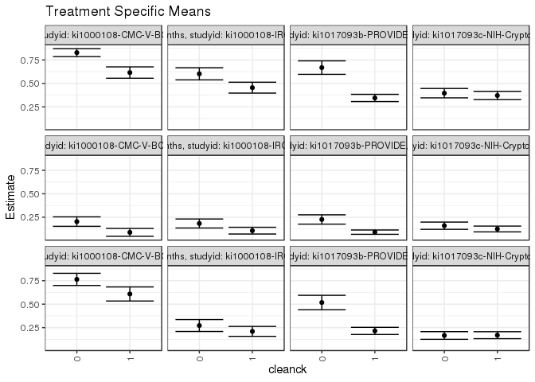

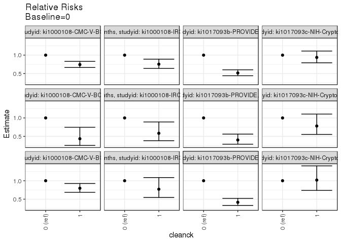

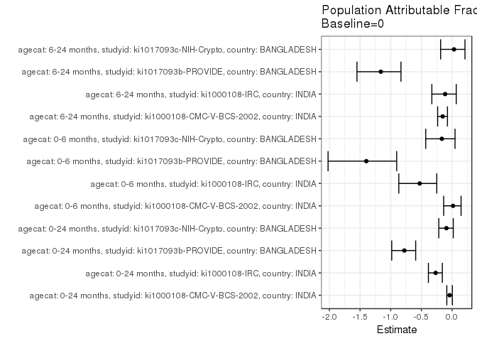

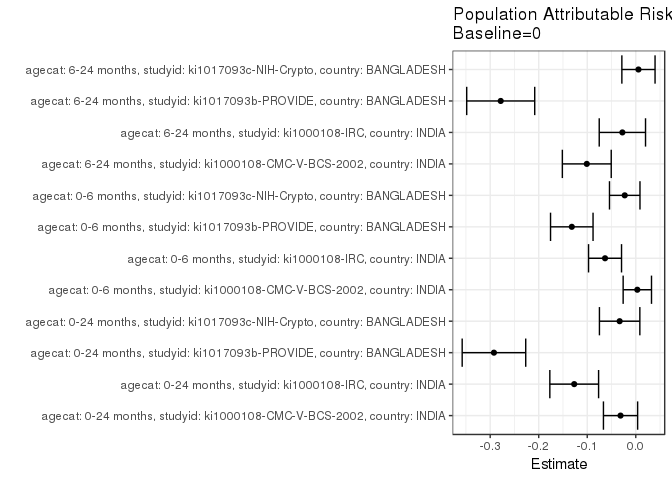

## Results Table

### Parameter: TSM

| agecat | studyid | country | intervention_level | baseline_level | estimate | ci_lower | ci_upper |
| --- | --- | --- | --- | --- | --- | --- | --- |
| 0-24 months | ki1000108-CMC-V-BCS-2002 | INDIA | 0 | NA | 0.8276304 | 0.7853553 | 0.8699054 |
| 0-24 months | ki1000108-CMC-V-BCS-2002 | INDIA | 1 | NA | 0.6153097 | 0.5549424 | 0.6756770 |
| 0-24 months | ki1000108-IRC | INDIA | 0 | NA | 0.6018449 | 0.5372517 | 0.6664381 |
| 0-24 months | ki1000108-IRC | INDIA | 1 | NA | 0.4542343 | 0.3962286 | 0.5122400 |
| 0-24 months | ki1017093b-PROVIDE | BANGLADESH | 0 | NA | 0.6679647 | 0.5959629 | 0.7399665 |
| 0-24 months | ki1017093b-PROVIDE | BANGLADESH | 1 | NA | 0.3446803 | 0.3062406 | 0.3831200 |
| 0-24 months | ki1017093c-NIH-Crypto | BANGLADESH | 0 | NA | 0.3954483 | 0.3454850 | 0.4454117 |
| 0-24 months | ki1017093c-NIH-Crypto | BANGLADESH | 1 | NA | 0.3708570 | 0.3269354 | 0.4147786 |
| 0-6 months | ki1000108-CMC-V-BCS-2002 | INDIA | 0 | NA | 0.2033111 | 0.1528492 | 0.2537729 |
| 0-6 months | ki1000108-CMC-V-BCS-2002 | INDIA | 1 | NA | 0.0887257 | 0.0469501 | 0.1305012 |
| 0-6 months | ki1000108-IRC | INDIA | 0 | NA | 0.1833199 | 0.1352040 | 0.2314359 |
| 0-6 months | ki1000108-IRC | INDIA | 1 | NA | 0.1070763 | 0.0710055 | 0.1431472 |
| 0-6 months | ki1017093b-PROVIDE | BANGLADESH | 0 | NA | 0.2261162 | 0.1765125 | 0.2757200 |
| 0-6 months | ki1017093b-PROVIDE | BANGLADESH | 1 | NA | 0.0909471 | 0.0679673 | 0.1139270 |
| 0-6 months | ki1017093c-NIH-Crypto | BANGLADESH | 0 | NA | 0.1596479 | 0.1210545 | 0.1982413 |
| 0-6 months | ki1017093c-NIH-Crypto | BANGLADESH | 1 | NA | 0.1247554 | 0.0939166 | 0.1555941 |
| 6-24 months | ki1000108-CMC-V-BCS-2002 | INDIA | 0 | NA | 0.7641205 | 0.6994468 | 0.8287942 |
| 6-24 months | ki1000108-CMC-V-BCS-2002 | INDIA | 1 | NA | 0.6086406 | 0.5334819 | 0.6837993 |
| 6-24 months | ki1000108-IRC | INDIA | 0 | NA | 0.2722995 | 0.2087142 | 0.3358848 |
| 6-24 months | ki1000108-IRC | INDIA | 1 | NA | 0.2097856 | 0.1569433 | 0.2626279 |
| 6-24 months | ki1017093b-PROVIDE | BANGLADESH | 0 | NA | 0.5177520 | 0.4410183 | 0.5944858 |
| 6-24 months | ki1017093b-PROVIDE | BANGLADESH | 1 | NA | 0.2151402 | 0.1769602 | 0.2533202 |
| 6-24 months | ki1017093c-NIH-Crypto | BANGLADESH | 0 | NA | 0.1662945 | 0.1255644 | 0.2070245 |
| 6-24 months | ki1017093c-NIH-Crypto | BANGLADESH | 1 | NA | 0.1692706 | 0.1323359 | 0.2062053 |

### Parameter: E(Y)

| agecat | studyid | country | intervention_level | baseline_level | estimate | ci_lower | ci_upper |
| --- | --- | --- | --- | --- | --- | --- | --- |
| 0-24 months | ki1000108-CMC-V-BCS-2002 | INDIA | NA | NA | 0.7962466 | 0.7553156 | 0.8371777 |
| 0-24 months | ki1000108-IRC | INDIA | NA | NA | 0.4750000 | 0.4260009 | 0.5239991 |
| 0-24 months | ki1017093b-PROVIDE | BANGLADESH | NA | NA | 0.3757143 | 0.3398113 | 0.4116172 |
| 0-24 months | ki1017093c-NIH-Crypto | BANGLADESH | NA | NA | 0.3622184 | 0.3229667 | 0.4014700 |
| 0-6 months | ki1000108-CMC-V-BCS-2002 | INDIA | NA | NA | 0.2065217 | 0.1651060 | 0.2479375 |
| 0-6 months | ki1000108-IRC | INDIA | NA | NA | 0.1200000 | 0.0881145 | 0.1518855 |
| 0-6 months | ki1017093b-PROVIDE | BANGLADESH | NA | NA | 0.0942857 | 0.0726222 | 0.1159492 |
| 0-6 months | ki1017093c-NIH-Crypto | BANGLADESH | NA | NA | 0.1369151 | 0.1088421 | 0.1649881 |
| 6-24 months | ki1000108-CMC-V-BCS-2002 | INDIA | NA | NA | 0.6631944 | 0.6085159 | 0.7178730 |
| 6-24 months | ki1000108-IRC | INDIA | NA | NA | 0.2447130 | 0.1983282 | 0.2910978 |
| 6-24 months | ki1017093b-PROVIDE | BANGLADESH | NA | NA | 0.2394366 | 0.2018814 | 0.2769918 |
| 6-24 months | ki1017093c-NIH-Crypto | BANGLADESH | NA | NA | 0.1718427 | 0.1381646 | 0.2055207 |

### Parameter: RR

| agecat | studyid | country | intervention_level | baseline_level | estimate | ci_lower | ci_upper |
| --- | --- | --- | --- | --- | --- | --- | --- |
| 0-24 months | ki1000108-CMC-V-BCS-2002 | INDIA | 0 | 0 | 1.0000000 | 1.0000000 | 1.0000000 |
| 0-24 months | ki1000108-CMC-V-BCS-2002 | INDIA | 1 | 0 | 0.7434596 | 0.6653495 | 0.8307396 |
| 0-24 months | ki1000108-IRC | INDIA | 0 | 0 | 1.0000000 | 1.0000000 | 1.0000000 |
| 0-24 months | ki1000108-IRC | INDIA | 1 | 0 | 0.7547365 | 0.6394334 | 0.8908311 |
| 0-24 months | ki1017093b-PROVIDE | BANGLADESH | 0 | 0 | 1.0000000 | 1.0000000 | 1.0000000 |
| 0-24 months | ki1017093b-PROVIDE | BANGLADESH | 1 | 0 | 0.5160158 | 0.4419853 | 0.6024460 |
| 0-24 months | ki1017093c-NIH-Crypto | BANGLADESH | 0 | 0 | 1.0000000 | 1.0000000 | 1.0000000 |
| 0-24 months | ki1017093c-NIH-Crypto | BANGLADESH | 1 | 0 | 0.9378140 | 0.7918941 | 1.1106221 |
| 0-6 months | ki1000108-CMC-V-BCS-2002 | INDIA | 0 | 0 | 1.0000000 | 1.0000000 | 1.0000000 |
| 0-6 months | ki1000108-CMC-V-BCS-2002 | INDIA | 1 | 0 | 0.4364036 | 0.2552254 | 0.7461958 |
| 0-6 months | ki1000108-IRC | INDIA | 0 | 0 | 1.0000000 | 1.0000000 | 1.0000000 |
| 0-6 months | ki1000108-IRC | INDIA | 1 | 0 | 0.5840955 | 0.3828754 | 0.8910668 |
| 0-6 months | ki1017093b-PROVIDE | BANGLADESH | 0 | 0 | 1.0000000 | 1.0000000 | 1.0000000 |
| 0-6 months | ki1017093b-PROVIDE | BANGLADESH | 1 | 0 | 0.4022140 | 0.2878098 | 0.5620938 |
| 0-6 months | ki1017093c-NIH-Crypto | BANGLADESH | 0 | 0 | 1.0000000 | 1.0000000 | 1.0000000 |
| 0-6 months | ki1017093c-NIH-Crypto | BANGLADESH | 1 | 0 | 0.7814407 | 0.5529988 | 1.1042513 |
| 6-24 months | ki1000108-CMC-V-BCS-2002 | INDIA | 0 | 0 | 1.0000000 | 1.0000000 | 1.0000000 |
| 6-24 months | ki1000108-CMC-V-BCS-2002 | INDIA | 1 | 0 | 0.7965244 | 0.6857188 | 0.9252351 |
| 6-24 months | ki1000108-IRC | INDIA | 0 | 0 | 1.0000000 | 1.0000000 | 1.0000000 |
| 6-24 months | ki1000108-IRC | INDIA | 1 | 0 | 0.7704222 | 0.5464879 | 1.0861180 |
| 6-24 months | ki1017093b-PROVIDE | BANGLADESH | 0 | 0 | 1.0000000 | 1.0000000 | 1.0000000 |
| 6-24 months | ki1017093b-PROVIDE | BANGLADESH | 1 | 0 | 0.4155275 | 0.3306077 | 0.5222598 |
| 6-24 months | ki1017093c-NIH-Crypto | BANGLADESH | 0 | 0 | 1.0000000 | 1.0000000 | 1.0000000 |
| 6-24 months | ki1017093c-NIH-Crypto | BANGLADESH | 1 | 0 | 1.0178970 | 0.7381410 | 1.4036806 |

### Parameter: PAR

| agecat | studyid | country | intervention_level | baseline_level | estimate | ci_lower | ci_upper |
| --- | --- | --- | --- | --- | --- | --- | --- |
| 0-24 months | ki1000108-CMC-V-BCS-2002 | INDIA | 0 | NA | -0.0313837 | -0.0666082 | 0.0038407 |
| 0-24 months | ki1000108-IRC | INDIA | 0 | NA | -0.1268449 | -0.1770768 | -0.0766130 |
| 0-24 months | ki1017093b-PROVIDE | BANGLADESH | 0 | NA | -0.2922504 | -0.3577229 | -0.2267779 |
| 0-24 months | ki1017093c-NIH-Crypto | BANGLADESH | 0 | NA | -0.0332299 | -0.0748608 | 0.0084009 |
| 0-6 months | ki1000108-CMC-V-BCS-2002 | INDIA | 0 | NA | 0.0032107 | -0.0260004 | 0.0324218 |
| 0-6 months | ki1000108-IRC | INDIA | 0 | NA | -0.0633199 | -0.0973074 | -0.0293325 |
| 0-6 months | ki1017093b-PROVIDE | BANGLADESH | 0 | NA | -0.1318305 | -0.1756316 | -0.0880295 |
| 0-6 months | ki1017093c-NIH-Crypto | BANGLADESH | 0 | NA | -0.0227328 | -0.0541449 | 0.0086793 |
| 6-24 months | ki1000108-CMC-V-BCS-2002 | INDIA | 0 | NA | -0.1009261 | -0.1512936 | -0.0505585 |
| 6-24 months | ki1000108-IRC | INDIA | 0 | NA | -0.0275865 | -0.0752876 | 0.0201146 |
| 6-24 months | ki1017093b-PROVIDE | BANGLADESH | 0 | NA | -0.2783154 | -0.3483895 | -0.2082413 |
| 6-24 months | ki1017093c-NIH-Crypto | BANGLADESH | 0 | NA | 0.0055482 | -0.0286458 | 0.0397422 |

### Parameter: PAF

| agecat | studyid | country | intervention_level | baseline_level | estimate | ci_lower | ci_upper |
| --- | --- | --- | --- | --- | --- | --- | --- |
| 0-24 months | ki1000108-CMC-V-BCS-2002 | INDIA | 0 | NA | -0.0394146 | -0.0854759 | 0.0046922 |
| 0-24 months | ki1000108-IRC | INDIA | 0 | NA | -0.2670419 | -0.3855388 | -0.1586794 |
| 0-24 months | ki1017093b-PROVIDE | BANGLADESH | 0 | NA | -0.7778527 | -0.9840173 | -0.5931113 |
| 0-24 months | ki1017093c-NIH-Crypto | BANGLADESH | 0 | NA | -0.0917401 | -0.2160131 | 0.0198326 |
| 0-6 months | ki1000108-CMC-V-BCS-2002 | INDIA | 0 | NA | 0.0155465 | -0.1365693 | 0.1473034 |
| 0-6 months | ki1000108-IRC | INDIA | 0 | NA | -0.5276660 | -0.8684367 | -0.2490460 |
| 0-6 months | ki1017093b-PROVIDE | BANGLADESH | 0 | NA | -1.3982025 | -2.0221783 | -0.9030563 |
| 0-6 months | ki1017093c-NIH-Crypto | BANGLADESH | 0 | NA | -0.1660358 | -0.4292392 | 0.0486970 |
| 6-24 months | ki1000108-CMC-V-BCS-2002 | INDIA | 0 | NA | -0.1521817 | -0.2349599 | -0.0749521 |
| 6-24 months | ki1000108-IRC | INDIA | 0 | NA | -0.1127301 | -0.3293537 | 0.0685939 |
| 6-24 months | ki1017093b-PROVIDE | BANGLADESH | 0 | NA | -1.1623762 | -1.5508916 | -0.8330339 |
| 6-24 months | ki1017093c-NIH-Crypto | BANGLADESH | 0 | NA | 0.0322865 | -0.1865751 | 0.2107795 |